# p8105_hw6_kl3181

Kelley Lou

```r
library(tidyverse)
library(modelr)
library(p8105.datasets)
```

### Problem 1

```r
homicide_df =
  read_csv("data/homicide-data.csv", na = c("", "NA", "Unknown")) %>%
  mutate(
    city_state = str_c(city, state, sep = ", "),
    victim_age = as.numeric(victim_age),
    resolution = case_when(
      disposition == "Closed without arrest" ~ 0,
      disposition == "Open/No arrest"        ~ 0,
      disposition == "Closed by arrest"      ~ 1)
  ) %>%
  filter(
    victim_race %in% c("White", "Black"),
    city_state != "Tulsa, AL") %>%
  select(city_state, resolution, victim_age, victim_race, victim_sex)
```

Start with one city.

```r
baltimore_df =
  homicide_df %>%
  filter(city_state == "Baltimore, MD")
glm(resolution ~ victim_age + victim_race + victim_sex,
    data = baltimore_df,
    family = binomial()) %>%
  broom::tidy() %>%
  mutate(
    OR = exp(estimate),
    CI_lower = exp(estimate - 1.96 * std.error),
    CI_upper = exp(estimate + 1.96 * std.error)
  ) %>%
  select(term, OR, starts_with("CI")) %>%
  knitr::kable(digits = 3)
```

| term | OR | CI_lower | CI_upper |
| --- | --- | --- | --- |
| (Intercept) | 1.363 | 0.975 | 1.907 |
| victim_age | 0.993 | 0.987 | 1.000 |
| victim_raceWhite | 2.320 | 1.648 | 3.268 |
| victim_sexMale | 0.426 | 0.325 | 0.558 |

Try this across cities.

```r
models_results_df =
  homicide_df %>%
  nest(data = -city_state) %>%
  mutate(
    models =
      map(.x = data, ~glm(resolution ~ victim_age + victim_race + victim_sex, data = .x, family = binomial())),
    results = map(models, broom::tidy)
  ) %>%
  select(city_state, results) %>%
  unnest(results) %>%
  mutate(
    OR = exp(estimate),
    CI_lower = exp(estimate - 1.96 * std.error),
    CI_upper = exp(estimate + 1.96 * std.error)
  ) %>%
  select(city_state, term, OR, starts_with("CI"))
```

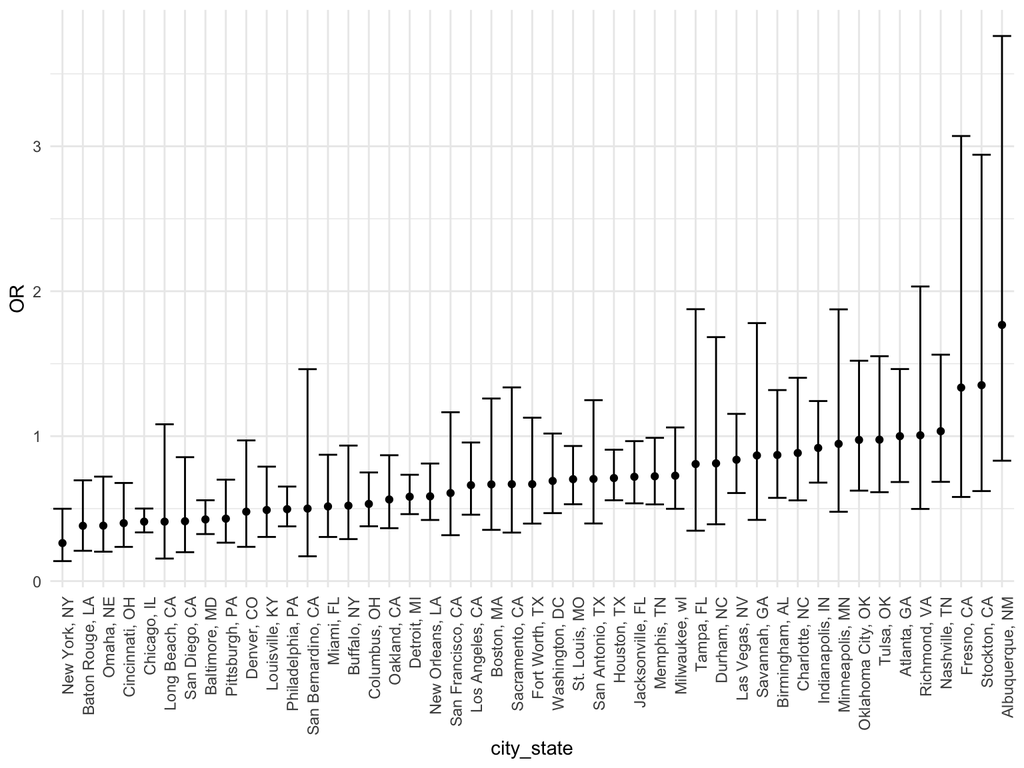

```r
models_results_df %>%
  filter(term == "victim_sexMale") %>%
  mutate(city_state = fct_reorder(city_state, OR)) %>%
  ggplot(aes(x = city_state, y = OR)) +
  geom_point() +
  geom_errorbar(aes(ymin = CI_lower, ymax = CI_upper)) +
  theme(axis.text.x = element_text(angle = 90, hjust = 1))
```

## Problem 2

### Read in datset and tidy.

```r
baby_df =
  read_csv("./data/birthweight.csv", na = c("", "NA", "Unknown")) %>%
  mutate(
    babysex = as.factor(babysex),
    mrace = as.factor(mrace),
    malform = as.factor(malform),
    frace = as.factor(frace))
```

Checking NAs

```r
count_na =
  baby_df %>%
  map_df(~sum(is.na(.)))
```

There are no NAs in the dataframe.

### Build regression model to predict birthweight.

To build my model, I will first create a full model, then remove insignificant variables using a backward step-wise elimination.

```r
# First fitting a model with all variables in the dataset
full_model = lm(bwt ~ ., data = baby_df)

step(full_model, direction = "backward")
```

```
## Start:  AIC=48717.83
## bwt ~ babysex + bhead + blength + delwt + fincome + frace + gaweeks +
##     malform + menarche + mheight + momage + mrace + parity +
##     pnumlbw + pnumsga + ppbmi + ppwt + smoken + wtgain
##
##
## Step:  AIC=48717.83
## bwt ~ babysex + bhead + blength + delwt + fincome + frace + gaweeks +
##     malform + menarche + mheight + momage + mrace + parity +
##     pnumlbw + pnumsga + ppbmi + ppwt + smoken
##
##
## Step:  AIC=48717.83
## bwt ~ babysex + bhead + blength + delwt + fincome + frace + gaweeks +
##     malform + menarche + mheight + momage + mrace + parity +
##     pnumlbw + ppbmi + ppwt + smoken
##
##
## Step:  AIC=48717.83
## bwt ~ babysex + bhead + blength + delwt + fincome + frace + gaweeks +
##     malform + menarche + mheight + momage + mrace + parity +
##     ppbmi + ppwt + smoken
##
##            Df Sum of Sq       RSS   AIC
## - frace     4    124365 320848704 48712
## - malform   1      1419 320725757 48716
## - ppbmi     1      6346 320730684 48716
## - momage    1     28661 320752999 48716
## - mheight   1     66886 320791224 48717
## - menarche  1    111679 320836018 48717
## - ppwt      1    131132 320855470 48718
## <none>                  320724338 48718
## - fincome   1    193454 320917792 48718
## - parity    1    413584 321137922 48721
## - mrace     3    868321 321592659 48724
## - babysex   1    853796 321578134 48727
## - gaweeks   1   4611823 325336161 48778
## - smoken    1   5076393 325800732 48784
## - delwt     1   8008891 328733230 48823
## - blength   1 102050296 422774634 49915
```

[output cut: 88 more lines]

```
##     mheight + mrace + parity + ppwt + smoken
##
##           Df Sum of Sq       RSS   AIC
## <none>                 320986412 48705
## - fincome  1    245637 321232048 48707
## - parity   1    422770 321409181 48709
## - babysex  1    846134 321832545 48715
## - mheight  1   1012240 321998651 48717
## - ppwt     1   2907049 323893461 48743
## - gaweeks  1   4662501 325648912 48766
## - smoken   1   5073849 326060260 48771
## - delwt    1   8137459 329123871 48812
## - mrace    3  14683609 335670021 48894
## - blength  1 102191779 423178191 49903
## - bhead    1 106779754 427766166 49950
```

```
##
## Call:
## lm(formula = bwt ~ babysex + bhead + blength + delwt + fincome +
##     gaweeks + mheight + mrace + parity + ppwt + smoken, data = baby_df)
##
## Coefficients:
## (Intercept)     babysex2        bhead      blength        delwt      fincome
##   -6098.822       28.558      130.777       74.947        4.107        0.318
##     gaweeks      mheight       mrace2       mrace3       mrace4       parity
##      11.592        6.594     -138.792      -74.887     -100.678       96.305
##        ppwt       smoken
##      -2.676       -4.843
```

```r
# The output provides the following model to have the smallest AIC
model_1 = lm(bwt ~ babysex + bhead + blength + delwt + fincome +
    gaweeks + mheight + mrace + parity + ppwt + smoken, data = baby_df)

model_1 %>%
  broom::tidy() %>%
  select(-std.error, -statistic) %>%
  knitr::kable()
```

| term | estimate | p.value |
| --- | --- | --- |
| (Intercept) | -6098.8219113 | 0.0000000 |
| babysex2 | 28.5580171 | 0.0007374 |
| bhead | 130.7770408 | 0.0000000 |
| blength | 74.9471109 | 0.0000000 |
| delwt | 4.1067316 | 0.0000000 |
| fincome | 0.3180229 | 0.0688436 |
| gaweeks | 11.5924873 | 0.0000000 |
| mheight | 6.5940377 | 0.0002231 |
| mrace2 | -138.7924801 | 0.0000000 |
| mrace3 | -74.8867755 | 0.0768374 |
| mrace4 | -100.6781427 | 0.0000002 |
| parity | 96.3046933 | 0.0170038 |
| ppwt | -2.6755853 | 0.0000000 |
| smoken | -4.8434197 | 0.0000000 |

Plotting residuals against fitted values

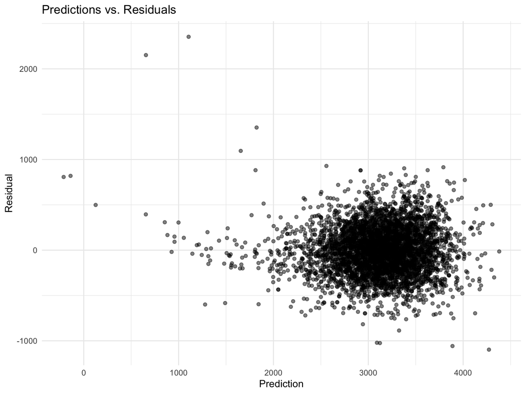

```r
baby_df %>%
  add_residuals(model_1) %>%
  add_predictions(model_1) %>%
  ggplot(aes(x = pred, y = resid)) +
  geom_point(alpha = 0.5) +
  labs(
    title = "Predictions vs. Residuals",
    x = "Prediction",
    y = "Residual"
  )
```

Looking at the distribution of residuals against fitted values, we can see that the most residuals are around 0, and around a predicted value of 3000. There are no clear patterns, but there are a few points that may be outliers.

### Compare model to other models

Creating model 2 and model 3

```r
model_2 = lm(bwt ~ blength + gaweeks, data = baby_df)

model_3 = lm(bwt ~ bhead * blength * babysex, data = baby_df)
```

Cross-validation of models

```r
# Map model across each sample
cv_df =
  crossv_mc(baby_df, 100) %>%
  mutate(
    train = map(train, as_tibble),
    test = map(test, as_tibble)
  )

cv_df =
  cv_df %>%
  mutate(
    model_1 = map(.x = train, ~lm(bwt ~ babysex + bhead + blength + delwt + fincome +
    gaweeks + mheight + mrace + parity + ppwt + smoken, data = .x)),
    model_2 = map(.x = train, ~lm(bwt ~ blength + gaweeks, data = .x)),
    model_3 = map(.x = train, ~lm(bwt ~ bhead * blength * babysex, data = .x))
  ) %>%
  mutate(
    rmse_model_1 = map2_dbl(model_1, test, ~rmse(model = .x, data = .y)),
    rmse_model_2 = map2_dbl(model_2, test, ~rmse(model = .x, data = .y)),
    rmse_model_3 = map2_dbl(model_3, test, ~rmse(model = .x, data = .y))
    )
```

Check RMSEs to find the best model.

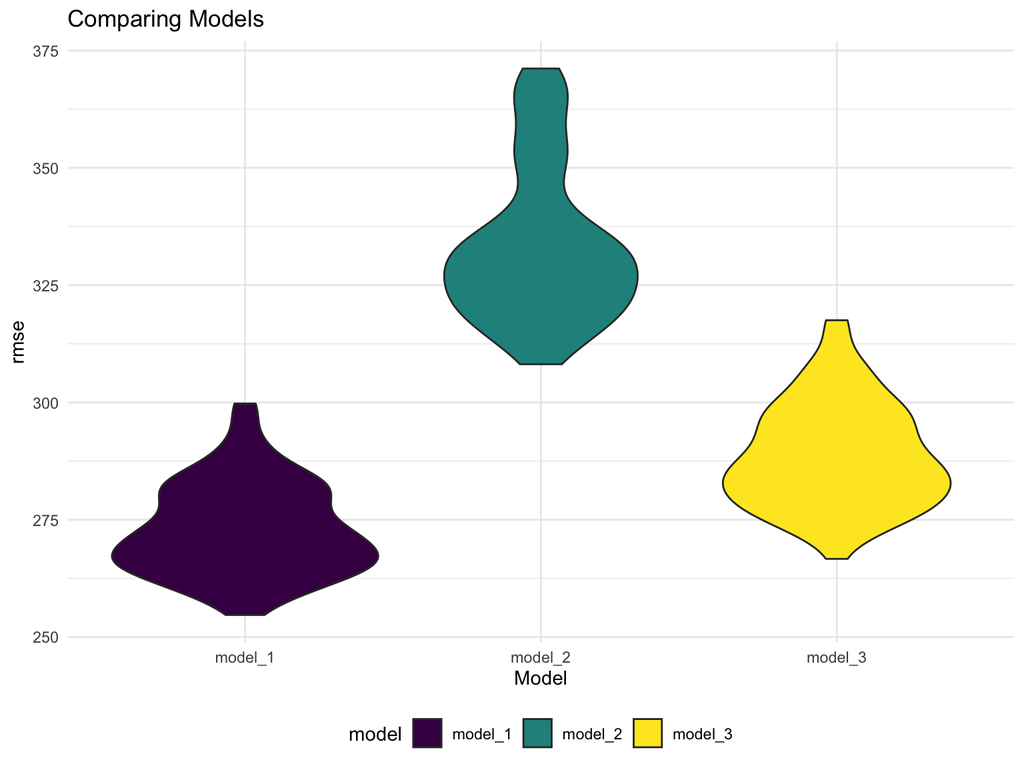

```r
cv_df %>%
  select(starts_with("rmse")) %>%
  pivot_longer(
    everything(),
    names_to = "model",
    values_to = "rmse",
    names_prefix = "rmse_") %>%
  ggplot(aes(x = model, y = rmse)) +
  geom_violin(aes(fill = model)) +
  labs(
    title = "Comparing Models",
    x = "Model",
    y = "rmse"
  )
```

Looking at the models, we can see that model 1 has the lowest RMSE, indicating that it is the best model out of the three.

## Problem 3

Import data.

```r
weather_df =
  rnoaa::meteo_pull_monitors(
    c("USW00094728"),
    var = c("PRCP", "TMIN", "TMAX"),
    date_min = "2017-01-01",
    date_max = "2017-12-31") %>%
  mutate(
    name = recode(id, USW00094728 = "CentralPark_NY"),
    tmin = tmin / 10,
    tmax = tmax / 10) %>%
  select(name, id, everything())
```

### Use 5000 bootstrap samples and, for each bootstrap sample, produce estimates of r̂2 and log(β̂ 0∗β1)

```r
bootstrap_results =
  weather_df %>%
  modelr::bootstrap(n = 5000, id = "strap_number") %>%
  mutate(
    models = map(.x = strap, ~ lm(tmax ~ tmin, data = .x)),
    r_squared = map(models, broom::glance),
    results = map(models, broom::tidy)
  ) %>%
  unnest(results, r_squared) %>%
  select(strap_number, term, estimate, r.squared)
```

Wrangling to calculate log(beta0*beta1)

```r
beta =
  bootstrap_results %>%
  select(strap_number, term, estimate) %>%
  pivot_wider(
    names_from = term,
    values_from = estimate
  ) %>%
  janitor::clean_names() %>%
  mutate(log_beta = log(intercept*tmin))

full_results = left_join(bootstrap_results, beta, by = "strap_number") %>%
  select(-intercept, -tmin)
```

### Look at distribution of r̂2 and log(beta0*beta1).

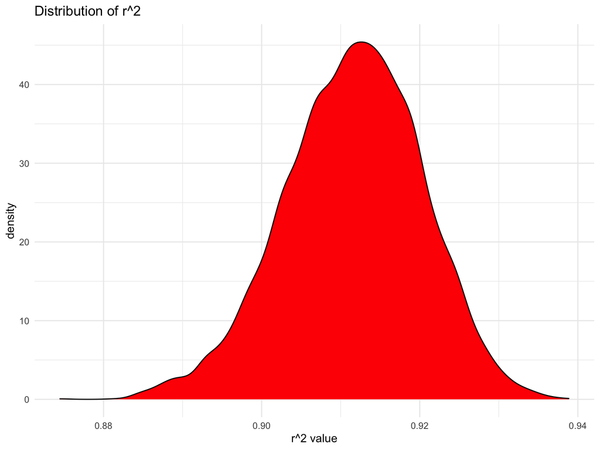

```r
full_results %>%
  ggplot(aes(x = r.squared)) +
  geom_density(fill = "red") +
  labs(
    title = "Distribution of r^2",
    x = "r^2 value"
  )
```

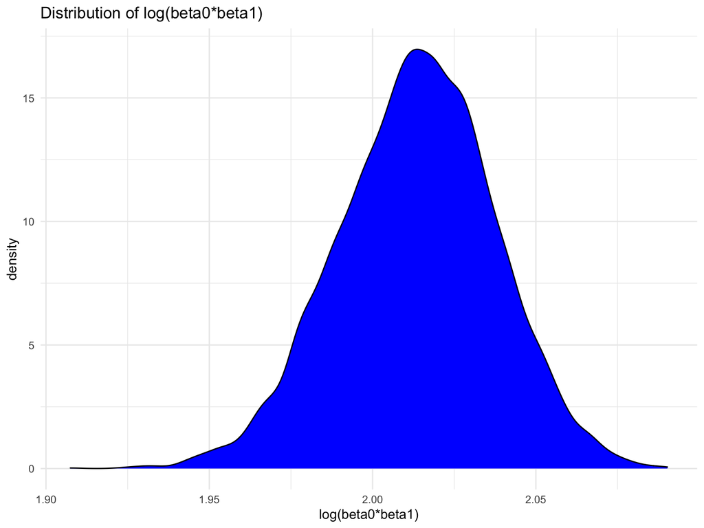

```r
full_results %>%
  ggplot(aes(x = log_beta)) +
  geom_density(fill = "blue") +
  labs(
    title = "Distribution of log(beta0*beta1)",
    x = "log(beta0*beta1)"
  )
```

The distribution of r squared is mostly normally distributed, centered round 0.91, with a slight left skew. The distribution of log(beta0*beta1) is very similar, centered around 2.02 without clear skewness.

### Finding 95% CI.

```r
full_results %>%
  pivot_longer(
    r.squared:log_beta,
    names_to = "parameter",
    values_to = "value") %>%
  group_by(parameter) %>%
  summarize(
    ci_lower = quantile(value, 0.025),
    ci_upper = quantile(value, 0.975)
  ) %>%
  knitr::kable(digits = 3)
```

| parameter | ci_lower | ci_upper |
| --- | --- | --- |
| log_beta | 1.965 | 2.058 |
| r.squared | 0.893 | 0.928 |